# Supplemental Analysis Code

Kurt Wilson

3/25/2021

This supplemental material is from The Environmental Null: Documenting the Changing Influence of Physical and Social Environments on Prehistoric Andean Diets by Kurt M. Wilson and Weston C. McCool. The corresponding author, Kurt M. Wilson, may be contacted at kurt.wilson@utah.edu. The code below is the complete code to rerun the analyses performed in the manuscript.

### Load packages used in this data creation and analysis

```r
#autocorrelation and collinearity
  library(ape)
  library(corrplot)

#gam
  library(mgcv)

#load color libraries
  library(viridis)
  library(scales)

#boot to calculate inverse of logit
  library(boot)

#weighted row mean and sd
  library(matrixStats)

#for mapping
library(maps)       # Provides functions that let us plot the maps
library(mapdata)    # Contains the hi-resolution points that mark out the countries.
library(raster)#mapping and working with spatial data
library(rgdal)#mapping and shapefile reading
library(ncdf4)#working with netcdf files
library(maptools)#mapping
library(sf)#shapefile reading and analysis
library(sp)#shapefile reading and analysis
library(rgeos)
library(spatstat) #enables creating owin object required for the stkde function in rcarbon
library(GISTools)
```

### Importing the data

All of the data for this analysis is available in the supplemental data file for Wilson et al. (submitted). The data may be downloaded as a csv. Once the csv file is downloaded, proceed with the code below.

Read in the csv data file - this file is available as a supplement to the article “Climate, not Population Size, is the Primary Influence of Homogenizing Dietary Variation in the Prehispanic Central Andes” by Wilson et al (submitted to *Science Advances*). This file has the data required for this analysis and some extra individuals we need to drop out.

```r
dat <- read.csv("Supplemental_Data_File_2_analysis_data.csv")

#Subset the data to keep only the individuals from our periods of interest
dat <- dat[which(dat$Period == "Early Intermediate Period" | dat$Period == "Middle Horizon" | dat$Period == "Late Intermediate Period" | dat$Period == "Late Horizon"),] #1601 individuals
```

Set up the individual dataframes for analyzing by time period.

```r
#Make sure elevation is reading as a numeric variable
dat$elevation <- as.numeric(dat$elevation)

#Set site.id as a factor so it may be used as a random effect in the GAM analyses
dat$Site.ID <- as.factor(dat$Site.ID)

#Generate tables for each time period
dat.eip <- dat[which(dat$Period == 'Early Intermediate Period'),] #321 individuals
dat.mh <- dat[which(dat$Period == 'Middle Horizon'),] #398 individuals
dat.lip <- dat[which(dat$Period == 'Late Intermediate Period'),] #625 individuals
dat.lh <- dat[which(dat$Period == 'Late Horizon'),] #257 individuals

dat.all <- dat
```

Let’s check if duration has an influence on the dependent variables (N & C)

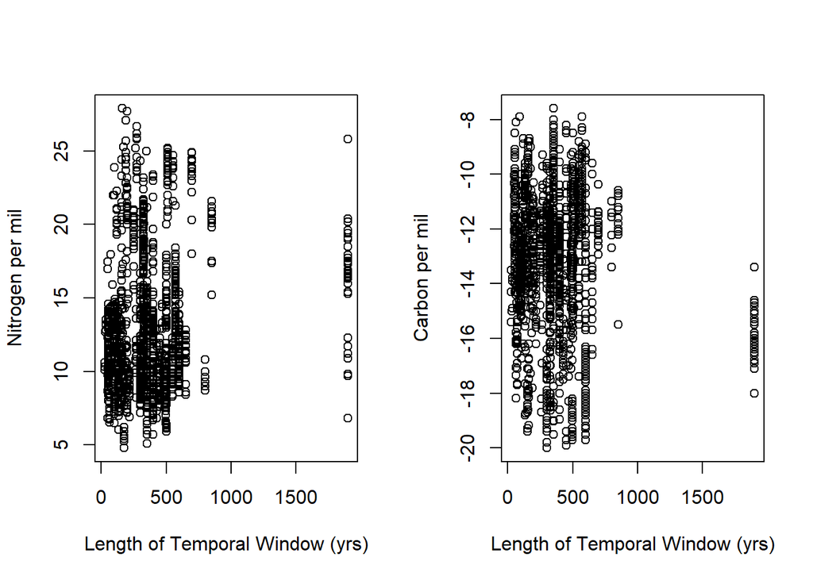

```r
#calculate the time window size for each individual
duration <- dat.all$Start.BP - dat.all$End.BP

#add this to our dat dataframe
dat.all <- cbind(dat.all, duration)

#subset the dataframe for nitrogen and carbon
dat.all.n <- dat.all[!is.na(dat.all$N.b.coll.),]
dat.all.c <- dat.all[!is.na(dat.all$C.b.coll.),]

#plot the relationship between time window size and nitrogen or carbon value
par(mfrow = c(1,2))
plot(dat.all.n$N.b.coll.~dat.all.n$duration, ylab = "Nitrogen per mil", xlab = "Length of Temporal Window (yrs)")

plot(dat.all.c$C.b.coll.~dat.all.c$duration, ylab = "Carbon per mil", xlab = "Length of Temporal Window (yrs)")
```

These plots show no signs of consistent patterning in length of time window and dietary isotope. Duration is not having an influence

### Generate summary statistics

First, make subsets for each time period and isotope

```r
#Generate subsets of the data for individuals with C and individuals with N by each time period
LH_C <- subset(dat.lh, !is.na(dat.lh$C.b.coll.))#leave out individuals with NA for N bone coll
LH_N <- subset(dat.lh, !is.na(dat.lh$N.b.coll.))#leave out individuals with NA for N bone coll

LIP_C <- subset(dat.lip, !is.na(dat.lip$C.b.coll.))#leave out individuals with NA for N bone coll
LIP_N <- subset(dat.lip, !is.na(dat.lip$N.b.coll.))#leave out individuals with NA for N bone coll

MH_C <- subset(dat.mh, !is.na(dat.mh$C.b.coll.))#leave out individuals with NA for N bone coll
MH_N <- subset(dat.mh, !is.na(dat.mh$N.b.coll.))#leave out individuals with NA for N bone coll

EIP_C <- subset(dat.eip, !is.na(dat.eip$C.b.coll.))#leave out individuals with NA for N bone coll
EIP_N <- subset(dat.eip, !is.na(dat.eip$N.b.coll.))#leave out individuals with NA for N bone coll
```

Calculate mean, median, and standard deviation of Nitrogen and Carbon for the EIP

```r
median(EIP_N$N.b.coll.)
```

```
## [1] 10.85
```

```r
mean(EIP_N$N.b.coll.)
```

```
## [1] 13.35222
```

```r
sd(EIP_N$N.b.coll.)
```

```
## [1] 5.818608
```

```r
median(EIP_C$C.b.coll.)
```

```
## [1] -14.7
```

```r
mean(EIP_C$C.b.coll.)
```

```
## [1] -14.94123
```

```r
sd(EIP_C$C.b.coll.)
```

```
## [1] 2.559686
```

```r
#Calculate the number of sites for the EIP
sites.EIPN <- unique(EIP_N$Site.ID)
length(sites.EIPN)
```

```
## [1] 41
```

```r
sites.EIPC <- unique(EIP_C$Site.ID)
length(sites.EIPC)
```

```
## [1] 41
```

Calculate mean, median, and standard deviation of Nitrogen and Carbon for the MH

```r
median(MH_N$N.b.coll.)
```

```
## [1] 9.9
```

```r
mean(MH_N$N.b.coll.)
```

```
## [1] 10.30047
```

```r
sd(MH_N$N.b.coll.)
```

```
## [1] 2.752424
```

```r
median(MH_C$C.b.coll.)
```

```
## [1] -12.2
```

```r
mean(MH_C$C.b.coll.)
```

```
## [1] -12.54928
```

```r
sd(MH_C$C.b.coll.)
```

```
## [1] 2.679752
```

```r
#Calculate the number of sites for the MH
sites.MHN <- unique(MH_N$Site.ID)
length(sites.MHN)
```

```
## [1] 36
```

```r
sites.MHC <- unique(MH_C$Site.ID)
length(sites.MHC)
```

```
## [1] 37
```

Calculate mean, median, and standard deviation of Nitrogen and Carbon for the LIP

```r
median(LIP_N$N.b.coll.)
```

```
## [1] 13.655
```

```r
mean(LIP_N$N.b.coll.)
```

```
## [1] 14.65948
```

```r
sd(LIP_N$N.b.coll.)
```

```
## [1] 3.639178
```

```r
median(LIP_C$C.b.coll.)
```

```
## [1] -12.61
```

```r
mean(LIP_C$C.b.coll.)
```

```
## [1] -12.87161
```

```r
sd(LIP_C$C.b.coll.)
```

```
## [1] 2.260049
```

```r
#Calculate the number of sites for the LIP

sites.LIPN <- unique(LIP_N$Site.ID)
length(sites.LIPN)
```

```
## [1] 34
```

```r
sites.LIPC <- unique(LIP_C$Site.ID)
length(sites.LIPC)
```

```
## [1] 37
```

Calculate mean, median, and standard deviation of Nitrogen and Carbon for the LH

```r
median(LH_N$N.b.coll.)
```

```
## [1] 10.6
```

```r
mean(LH_N$N.b.coll.)
```

```
## [1] 11.71118
```

```r
sd(LH_N$N.b.coll.)
```

```
## [1] 4.425484
```

```r
median(LH_C$C.b.coll.)
```

```
## [1] -11.6
```

```r
mean(LH_C$C.b.coll.)
```

```
## [1] -12.03167
```

```r
sd(LH_C$C.b.coll.)
```

```
## [1] 1.978016
```

```r
#Calculate the number of sites for the LH
sites.LHN <- unique(LH_N$Site.ID)
length(sites.LHN)
```

```
## [1] 10
```

```r
sites.LHC <- unique(LH_C$Site.ID)
length(sites.LHC)
```

```
## [1] 10
```

Calculate mean, median, and standard deviation of Nitrogen and Carbon for all individuals

```r
median(dat.all.n$N.b.coll.)
```

```
## [1] 11.58
```

```r
mean(dat.all.n$N.b.coll.)
```

```
## [1] 12.8469
```

```r
sd(dat.all.n$N.b.coll.)
```

```
## [1] 4.489576
```

```r
median(dat.all.c$C.b.coll.)
```

```
## [1] -12.6325
```

```r
mean(dat.all.c$C.b.coll.)
```

```
## [1] -13.06875
```

```r
sd(dat.all.c$C.b.coll.)
```

```
## [1] 2.580968
```

```r
#Calculate the number of sites
sites.allN <- unique(dat.all.n$Site.ID)
length(sites.allN)
```

```
## [1] 121
```

```r
sites.allC <- unique(dat.all.c$Site.ID)
length(sites.allC)
```

```
## [1] 125
```

Plot histograms of individuals by elevation for each time period to look at the range of variation.

Nitrogen

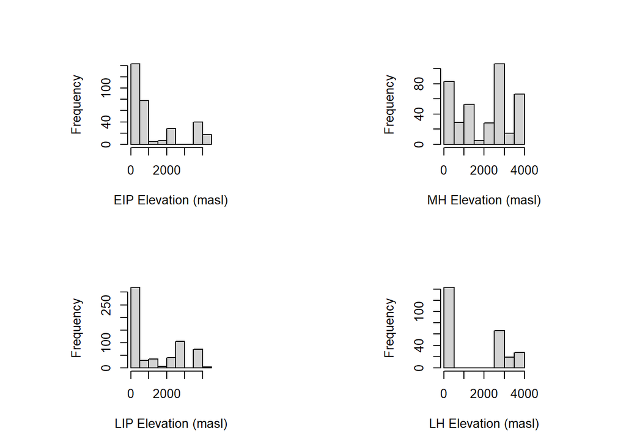

```r
par(pty = "s", mfrow = c(2,2))
hist(EIP_N$elevation, main = "", xlab = "EIP Elevation (masl)")
hist(MH_N$elevation, main = "", xlab = "MH Elevation (masl)")
hist(LIP_N$elevation, main = "", xlab = "LIP Elevation (masl)")
hist(LH_N$elevation, main = "", xlab = "LH Elevation (masl)")
```

In general there are more low than middle and high elevation individuals in the data, but this varies by time period.

Carbon

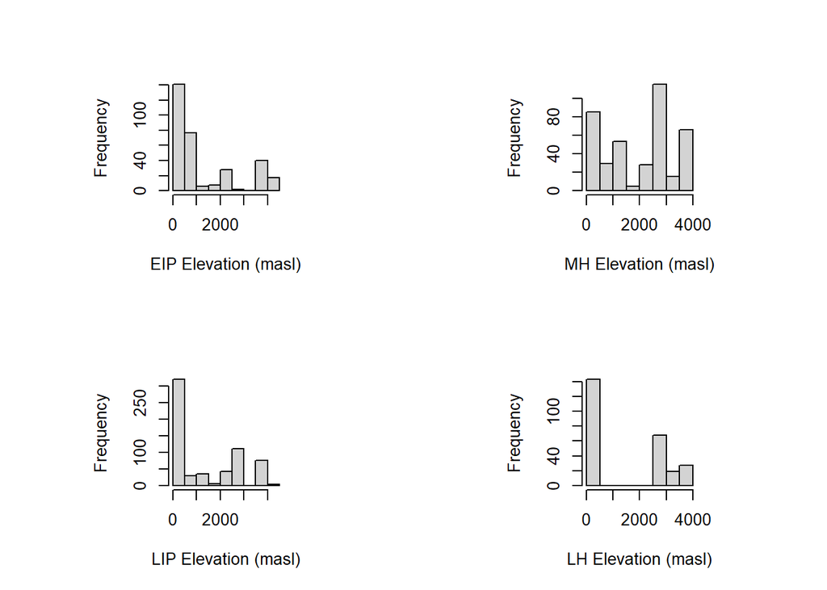

```r
par(pty = "s", mfrow = c(2,2))
hist(EIP_C$elevation, main = "", xlab = "EIP Elevation (masl)")
hist(MH_C$elevation, main = "", xlab = "MH Elevation (masl)")
hist(LIP_C$elevation, main = "", xlab = "LIP Elevation (masl)")
hist(LH_C$elevation, main = "", xlab = "LH Elevation (masl)")
```

In general there are more low than middle and high elevation individuals in the data, but this varies by time period.

Prep data for making Figure 2 - boxplots of isotope distribution by period

```r
dat.all.n.fc <- dat.all.n#make a new dataframe
dat.all.n.fc$Period <- as.factor(dat.all.n.fc$Period)#make Period a factor level
dat.all.c.fc <- dat.all.c
dat.all.c.fc$Period <- as.factor(dat.all.c.fc$Period)
```

Make Figure 2 - Boxplot for variation by time period

[figure not shown]

```r
#png("Fig2.boxplots.png", width=8, height=8, units="in", res=300)
par(pty="s", mfrow = c(1,2))
boxplot(dat.all.n.fc$N.b.coll.~dat.all.n.fc$Period, xlab = "Period", ylab = expression({delta}^15*N~'\u2030'), xaxt = "n", ylim = c(5,30), col = viridis(4))
axis(1, at = seq(1,4,1), labels = c("EIP", "MH", "LIP", "LH"))
boxplot(dat.all.c.fc$C.b.coll.~dat.all.c.fc$Period, xlab = "Period", ylab = expression({delta}^13*C~'\u2030'), xaxt = "n", ylim = c(-25, -5), col = viridis(4))
axis(1, at = seq(1,4,1), labels = c("EIP", "MH", "LIP", "LH"))
```

```r
#dev.off()
```

### Run the Analysis

##### Autocorrelation

First, check for cite autocorrelation as it may be reasonably expected that individuals at the same site would be more alike each other in terms of diet than they would be like individuals from other sites. If autocorrelation is present, this implies that site should be included in the statistical model as a random effect. We check for autocorrelation using Moran’s I.

```r
#build a simple matrix indicating if corresponding individual is
#of the same site.id, 0 = same site.id
site.dist.inv<-as.matrix(dist(as.numeric(dat.all$Site.ID)))

#set all values below 1 to -1, indicating that they are the same site.id
site.dist.inv[site.dist.inv < 1]<--1
#set all values above 1 to 0, indicating that they are not the same site.id
site.dist.inv[site.dist.inv > 1]<-0
#return negative values to 1, indicating that they are  the same site.id
site.dist.inv[site.dist.inv < 0]<-1

#calculate global Moran's I for nitrogen
data.frame("Site" = round(unlist(c(Moran.I(dat.all$N.b.coll., site.dist.inv, na.rm=T))), 4))
```

```
##             Site
## observed  0.4728
## expected -0.0006
## sd        0.0057
## p.value   0.0000
```

```r
#calculate global Moran's I for carbon
data.frame("Site" = round(unlist(c(Moran.I(dat.all$C.b.coll., site.dist.inv, na.rm=T))), 4))
```

```
##             Site
## observed  0.3613
## expected -0.0006
## sd        0.0056
## p.value   0.0000
```

There is significant autocorrelation in the response variables, indicating that individuals at the same site are more like one another than expected by chance. This is therefore controlled for in the GAM by including site.id as a random effect.

##### Collinearity and GAM Statistical Analyses

We expect most of the environmental variables to be linearly related to dietary measures. Because of this we keep these measures in the parametric portion of the GAMs. Doing so (keeping parametric) essentially makes the knots=1 (relationship can only vary in 1 direction). This also means that what we want to check for is collinearity among the predictors. However, we do want elevation to be able to vary more than once. This is because we would expect coastal signatures (marine) and high elevation (camelid herding) to have higher N values whereas mid-elevations may have lower ones. Therefore elevations needs to be made a smoothed term (which allows for more than one change in direction of variation). To check for collinearity we generate a correlation matrix of predictor variables. Any variables with a correlation coefficient above 0.7 may distort model estimation and will require removal of one of the variables - correlation coefficients under 0.7 are not likely to distort model estimation (Dormann et al 2013).

##### Generalized Additive Models (GAMs)

EIP Check for collinearity problems among the EIP individuals with Nitrogen values

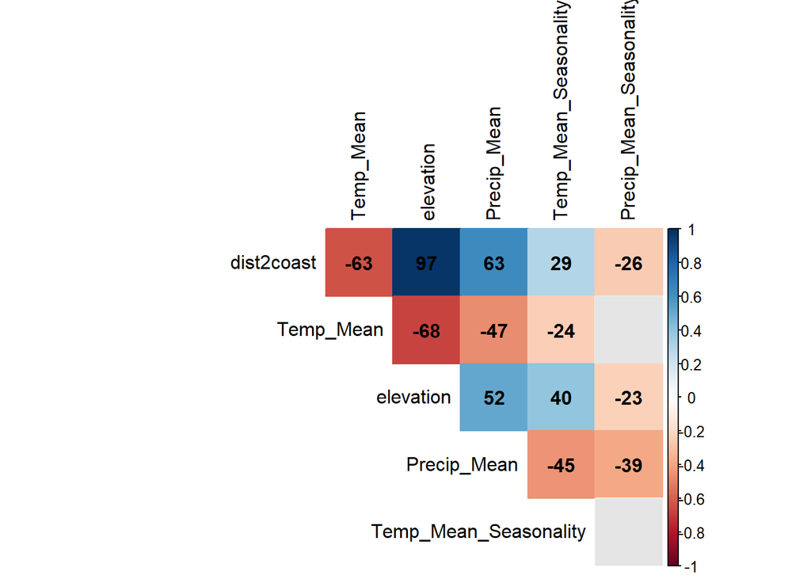

```r
#before calculate this reduce dataset to only those with N or C
EIP_N <- subset(dat.eip, !is.na(dat.eip$N.b.coll.))#leave out individuals with NA for N bone coll

EIP_N <- EIP_N[order(-EIP_N$Start.BP),]


#Create a function for identifying collinearity among variables
cor.mtest <- function(mat) {
    mat <- as.matrix(mat)
    n <- ncol(mat)
    p.mat<- matrix(NA, n, n)
    diag(p.mat) <- 0
    for (i in 1:(n - 1)) {
        for (j in (i + 1):n) {
            tmp <- cor.test(mat[, i], mat[, j])
            p.mat[i, j] <- p.mat[j, i] <- tmp$p.value
        }
    }
  colnames(p.mat) <- rownames(p.mat) <- colnames(mat)
  p.mat
}


#build a data frame of predictor variables
EIP_AllVars_Pred<-with(EIP_N,
             data.frame(
                    dist2coast, #Distance to the Coast (m)
                    Temp_Mean, #Mean Temperature (c)
                    elevation, #Elevation above sea level (masl)
                    Precip_Mean, #Mean Precipitation (mm)
                    Temp_Mean_Seasonality, #Mean seasonality of temperature over the year
                    Precip_Mean_Seasonality #Mean seasonality of precipitation over the year
             )
           )

#then test collinearity
cm<- cor(EIP_AllVars_Pred,
         method="pearson",
         use="pairwise.complete.obs")


# matrix of the p-value of the correlation
p.mat<-cor.mtest(EIP_AllVars_Pred)

#plot the correlation matrix
corrplot(cm,
      method="color",
      type="upper",
      diag=FALSE,
      bg="grey90",
      addCoef.col = "black",
      tl.col="black",
      outline = FALSE,
      addCoefasPercent=TRUE,
      p.mat = p.mat, sig.level = 0.05, insig = "blank"
  )
```

Elevation and dist2coast are highly correlated (>0.70) and therefore including both is problematic. We drop distance 2 coast in favor of elevation because elevation more directly relates to the natural zones (Pulgar Vidal 1981) than dist2coast. All other variables are < 0.70 in the collinearity matrix and therefore are fine to include in the model.

Then run the GAM for EIP individuals with Nitrogen values

```r
#Construct the GAM
#Note: Lat/Long are not included because doing so doesn't change the deviance explained but removes all of the variance explained by the environmental variables (in essence all of the climatic variables are correlated with lat/long so we drop lat/long in favor of exploring the individual environmental measures). Site.ID is included due to the demonstrated autocorrelation.

EIP.par.gam <- gam(N.b.coll.~ + s(Site.ID, bs = "re") + s(elevation)  + Temp_Mean  + Precip_Mean + Temp_Mean_Seasonality + Precip_Mean_Seasonality,
                     family = gaussian(link = "identity"),
                     method = "REML",
                     data=EIP_N[order(-EIP_N$Start.BP),]
                    )
```

Check the residuals

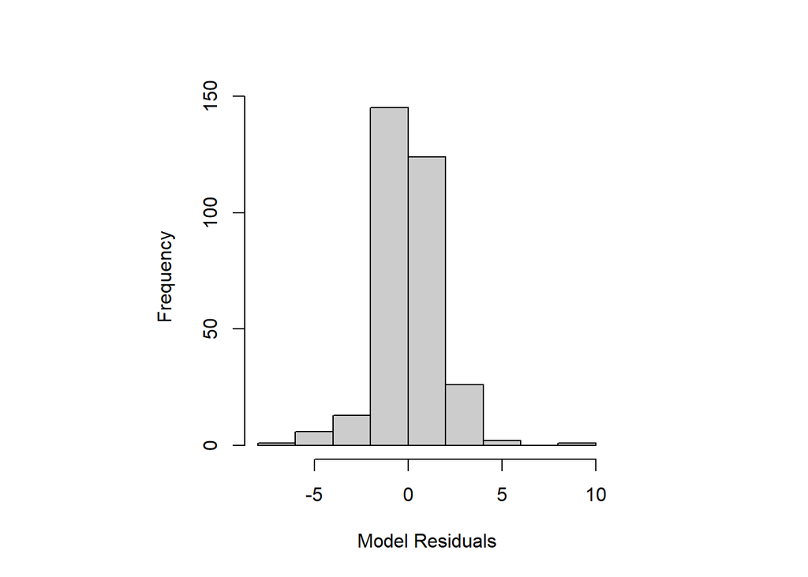

```r
#check model residuals
par(pty='s')
hist(residuals(EIP.par.gam, type = "response"), main = NA, xlab = "Model Residuals", col = "grey80")
```

```r
#residuals look good
```

The residuals are normally distributed around 0

Check for adequate smoothing of elevation

```r
k.check(EIP.par.gam)
```

```
##              k'       edf   k-index p-value
## s(Site.ID)   41 28.962539        NA      NA
## s(elevation)  9  4.710354 0.9740458   0.285
```

Elevation is adequately smoothed.

Check for overdispersion

```r
#check overdispersion
sum(residuals(EIP.par.gam, type = "pearson")^2) / df.residual(EIP.par.gam)
```

```
## [1] 2.950691
```

Overdispersion is not too strong.

Run the GAM summary for results

```r
summary(EIP.par.gam)
```

```
##
## Family: gaussian
## Link function: identity
##
## Formula:
## N.b.coll. ~ +s(Site.ID, bs = "re") + s(elevation) + Temp_Mean +
##     Precip_Mean + Temp_Mean_Seasonality + Precip_Mean_Seasonality
##
## Parametric coefficients:
##                          Estimate Std. Error t value Pr(>|t|)
## (Intercept)              42.19425    9.80461   4.304 2.33e-05 ***
## Temp_Mean                -1.02010    0.31921  -3.196  0.00155 **
## Precip_Mean              -3.10432    1.08414  -2.863  0.00451 **
## Temp_Mean_Seasonality     0.03965    0.02650   1.496  0.13574
## Precip_Mean_Seasonality -19.71880    4.59622  -4.290 2.46e-05 ***
## ---
## Signif. codes:  0 '***' 0.001 '**' 0.01 '*' 0.05 '.' 0.1 ' ' 1
##
## Approximate significance of smooth terms:
##                edf Ref.df      F  p-value
## s(Site.ID)   28.96 37.000 14.935  < 2e-16 ***
## s(elevation)  4.71  4.771  4.504 0.000549 ***
## ---
## Signif. codes:  0 '***' 0.001 '**' 0.01 '*' 0.05 '.' 0.1 ' ' 1
##
## R-sq.(adj) =  0.913   Deviance explained = 92.3%
## -REML = 686.32  Scale est. = 2.9507    n = 318
```

Check for collinearity problems among the EIP individuals with Carbon values

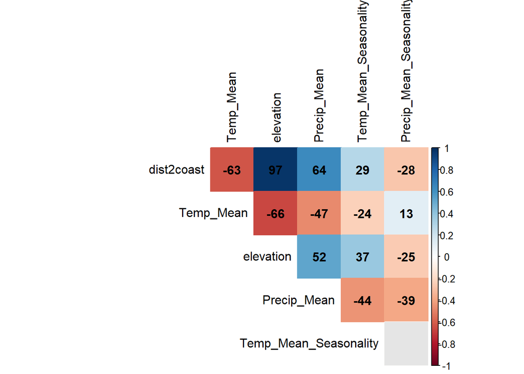

```r
#before calculate this reduce dataset to only those with N or C
EIP_C <- subset(dat.eip, !is.na(dat.eip$C.b.coll.))#leave out individuals with NA for C bone coll

#build a data frame of predictor variables
EIPC_AllVars_Pred<-with(EIP_C,
             data.frame(
                    dist2coast, #Distance to the Coast (m)
                    Temp_Mean, #Mean Temperature (c)
                    elevation, #Elevation above sea level (masl)
                    Precip_Mean, #Mean Precipitation (mm)
                    Temp_Mean_Seasonality, #Mean seasonality of temperature over the year
                    Precip_Mean_Seasonality #Mean seasonality of precipitation over the year
             )
           )

#then test collinearity
cm<- cor(EIPC_AllVars_Pred,
         method="pearson",
         use="pairwise.complete.obs")


# matrix of the p-value of the correlation
p.mat<-cor.mtest(EIPC_AllVars_Pred)

#plot the correlation matrix
corrplot(cm,
      method="color",
      type="upper",
      diag=FALSE,
      bg="grey90",
      addCoef.col = "black",
      tl.col="black",
      outline = FALSE,
      addCoefasPercent=TRUE,
      p.mat = p.mat, sig.level = 0.05, insig = "blank"
  )
```

Elevation and dist2coast are highly correlated (>0.70) and therefore including both is problematic. We drop distance 2 coast in favor of elevation. All other variables are < 0.70 in the collinearity matrix and therefore are fine to include in the model.

Run the GAM for individuals with carbon values

```r
EIPC.gam <- gam(C.b.coll.~ s(Site.ID, bs = "re") + Temp_Mean + s(elevation) + Precip_Mean + Temp_Mean_Seasonality + Precip_Mean_Seasonality,
                     family = gaussian(link = "identity"),
                     method = "REML",
                     data=EIP_C[order(-EIP_C$Start.BP),]
                    )
```

Check model residuals

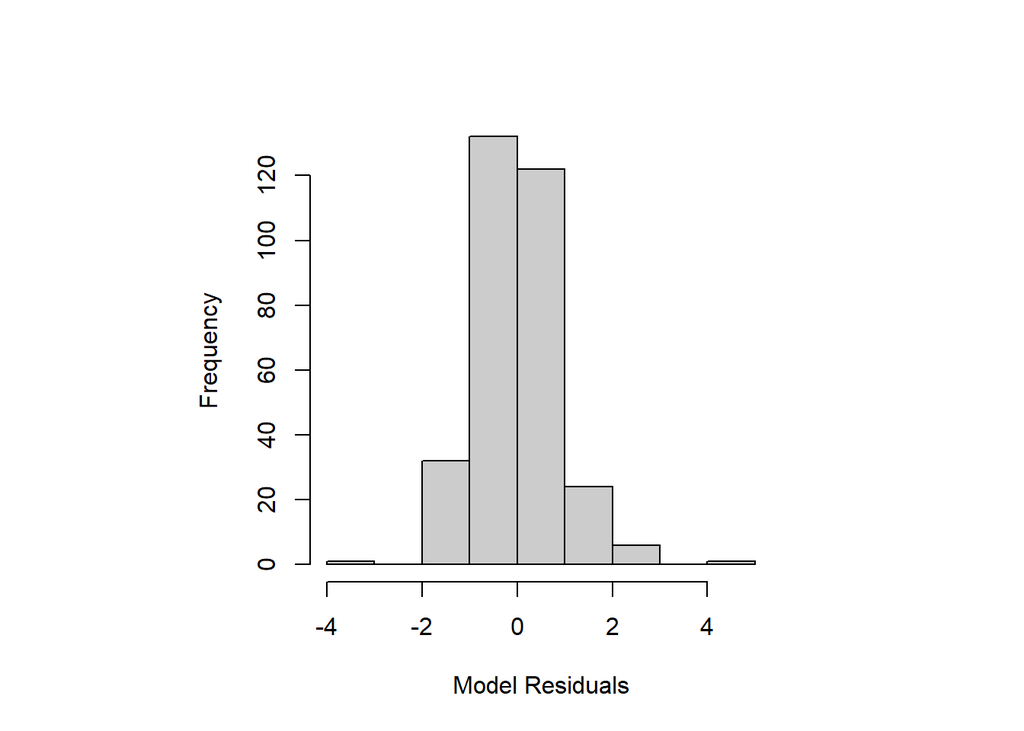

```r
par(pty='s')
hist(residuals(EIPC.gam, type = "response"), main = NA, xlab = "Model Residuals", col = "grey80")
```

The residuals are mostly normally distributed around 0.

Check to see if elevation is adequately smoothed

```r
k.check(EIPC.gam)
```

```
##              k'       edf  k-index p-value
## s(Site.ID)   41 27.316496       NA      NA
## s(elevation)  9  2.958668 1.048421  0.7925
```

Elevation is adequately smoothed

Check for overdispersion

```r
sum(residuals(EIPC.gam, type = "pearson")^2) / df.residual(EIPC.gam)
```

```
## [1] 0.812795
```

Residuals are not overdispersed

Run the GAM summary for results

```r
summary(EIPC.gam)
```

```
##
## Family: gaussian
## Link function: identity
##
## Formula:
## C.b.coll. ~ s(Site.ID, bs = "re") + Temp_Mean + s(elevation) +
##     Precip_Mean + Temp_Mean_Seasonality + Precip_Mean_Seasonality
##
## Parametric coefficients:
##                          Estimate Std. Error t value Pr(>|t|)
## (Intercept)             -3.297593   2.938599  -1.122   0.2627
## Temp_Mean               -0.229880   0.089835  -2.559   0.0110 *
## Precip_Mean             -0.552185   0.306923  -1.799   0.0731 .
## Temp_Mean_Seasonality   -0.011872   0.007235  -1.641   0.1019
## Precip_Mean_Seasonality -6.843415   1.421599  -4.814 2.41e-06 ***
## ---
## Signif. codes:  0 '***' 0.001 '**' 0.01 '*' 0.05 '.' 0.1 ' ' 1
##
## Approximate significance of smooth terms:
##                 edf Ref.df      F p-value
## s(Site.ID)   27.316 37.000  7.602  <2e-16 ***
## s(elevation)  2.959  3.077 21.131  <2e-16 ***
## ---
## Signif. codes:  0 '***' 0.001 '**' 0.01 '*' 0.05 '.' 0.1 ' ' 1
##
## R-sq.(adj) =  0.876   Deviance explained = 88.9%
## -REML = 466.24  Scale est. = 0.8128    n = 318
```

5.8B Middle Horizon

Check for collinearity problems among the MH individuals with Nitrogen values

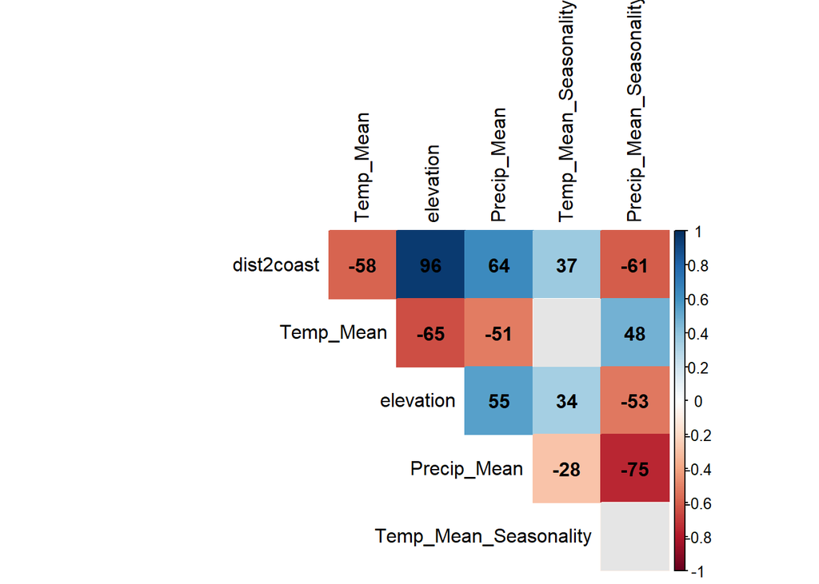

```r
#before calculate this reduce dataset to only those with N or C
MH_N <- subset(dat.mh, !is.na(dat.mh$N.b.coll.))#leave out individuals with NA for N bone coll


#build a data frame of predictor variables
MHN_AllVars_Pred<-with(MH_N,
             data.frame(
                    dist2coast, #Distance to the Coast (m)
                    Temp_Mean, #Mean Temperature (c)
                    elevation, #Elevation above sea level (masl)
                    Precip_Mean, #Mean Precipitation (mm)
                    Temp_Mean_Seasonality, #Mean seasonality of temperature over the year
                    Precip_Mean_Seasonality #Mean seasonality of precipitation over the year
             )
           )

#then test collinearity
cm<- cor(MHN_AllVars_Pred,
         method="pearson",
         use="pairwise.complete.obs")


# matrix of the p-value of the correlation
p.mat<-cor.mtest(MHN_AllVars_Pred)

#plot the correlation matrix
corrplot(cm,
      method="color",
      type="upper",
      diag=FALSE,
      bg="grey90",
      addCoef.col = "black",
      tl.col="black",
      outline = FALSE,
      addCoefasPercent=TRUE,
      p.mat = p.mat, sig.level = 0.05, insig = "blank"
  )
```

Elevation and dist2coast are highly correlated (>0.70) and therefore including both is problematic. We drop distance 2 coast in favor of elevation. Precip_Mean and Precip_Seasonality are also correlated >0.70. We drop Precip_Seasonality as a model with Precip_Mean outperforms the model with Precip_Seasonality based on AIC and we expect mean precipitation to be a more important factor in the underlying resource distributions.

Run the GAM for MH Nitrogen

```r
MHNgam <- gam(N.b.coll.~ s(Site.ID, bs = "re") + Temp_Mean + s(elevation) + Precip_Mean + Temp_Mean_Seasonality,
                     family = gaussian(link = "identity"),
                     method = "REML",
                     data=MH_N[order(-MH_N$Start.BP),]
                    )
```

Check model residuals

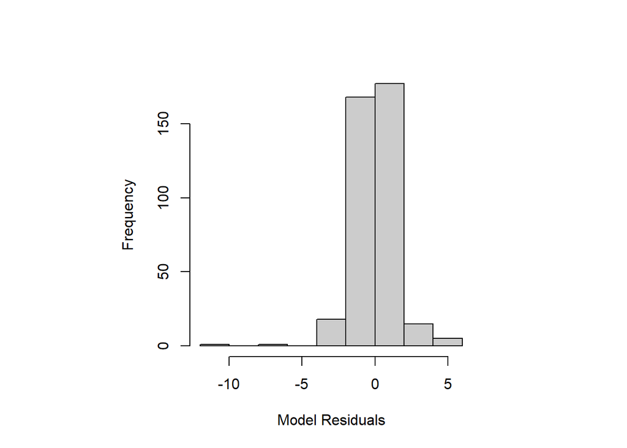

```r
par(pty='s')
hist(residuals(MHNgam, type = "response"), main = NA, xlab = "Model Residuals", col = "grey80")
```

Residuals are normally distributed around 0

Check to see if elevation is adequately smoothed

```r
k.check(MHNgam)
```

```
##              k'       edf   k-index p-value
## s(Site.ID)   36 26.233914        NA      NA
## s(elevation)  9  1.756632 0.9513992  0.1325
```

Elevation is adequately smoothed.

Check for overdispersion

```r
sum(residuals(MHNgam, type = "pearson")^2) / df.residual(MHNgam)
```

```
## [1] 2.280871
```

The model residuals are not overdispersed

Run the GAM summary for results

```r
summary(MHNgam)
```

```
##
## Family: gaussian
## Link function: identity
##
## Formula:
## N.b.coll. ~ s(Site.ID, bs = "re") + Temp_Mean + s(elevation) +
##     Precip_Mean + Temp_Mean_Seasonality
##
## Parametric coefficients:
##                       Estimate Std. Error t value Pr(>|t|)
## (Intercept)            3.88585    3.13027   1.241    0.215
## Temp_Mean              0.25738    0.17945   1.434    0.152
## Precip_Mean            0.08803    0.43297   0.203    0.839
## Temp_Mean_Seasonality  0.01999    0.01247   1.604    0.110
##
## Approximate significance of smooth terms:
##                 edf Ref.df      F p-value
## s(Site.ID)   26.234 35.000 14.795  <2e-16 ***
## s(elevation)  1.757  1.798  0.651   0.443
## ---
## Signif. codes:  0 '***' 0.001 '**' 0.01 '*' 0.05 '.' 0.1 ' ' 1
##
## R-sq.(adj) =  0.699   Deviance explained = 72.3%
## -REML = 752.13  Scale est. = 2.2809    n = 385
```

Check for collinearity problems among the MH individuals with Carbon values

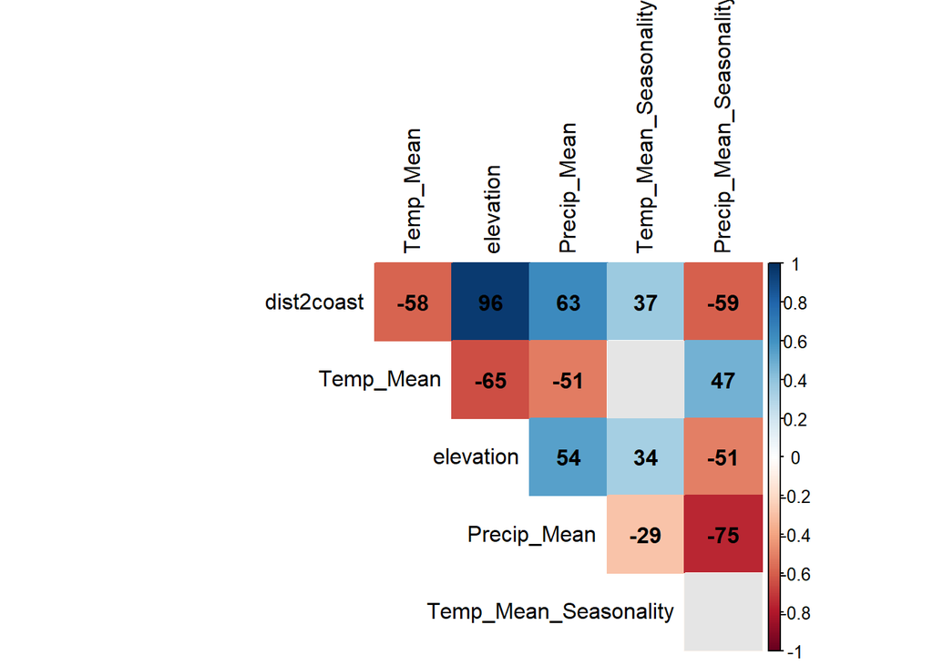

```r
#before calculate this reduce dataset to only those with N or C
MH_C <- subset(dat.mh, !is.na(dat.mh$C.b.coll.))#leave out individuals with NA for C bone coll


#build a data frame of predictor variables
MHC_AllVars_Pred<-with(MH_C,
             data.frame(
                    dist2coast, #Distance to the Coast (m)
                    Temp_Mean, #Mean Temperature (c)
                    elevation, #Elevation above sea level (masl)
                    Precip_Mean, #Mean Precipitation (mm)
                    Temp_Mean_Seasonality, #Mean seasonality of temperature over the year
                    Precip_Mean_Seasonality #Mean seasonality of precipitation over the year
             )
           )

#then test collinearity
cm<- cor(MHC_AllVars_Pred,
         method="pearson",
         use="pairwise.complete.obs")


# matrix of the p-value of the correlation
p.mat<-cor.mtest(MHC_AllVars_Pred)

#plot the correlation matrix
corrplot(cm,
      method="color",
      type="upper",
      diag=FALSE,
      bg="grey90",
      addCoef.col = "black",
      tl.col="black",
      outline = FALSE,
      addCoefasPercent=TRUE,
      p.mat = p.mat, sig.level = 0.05, insig = "blank"
  )
```

Elevation and dist2coast are highly correlated (>0.70) and therefore including both is problematic. We drop distance 2 coast in favor of elevation. Precip_Mean and Precip_Seasonality are also >0.70. We drop Precip_Seasonality as a model with Precip_Mean outperforms the model with Precip_Seasonality based on AIC and we expect mean precipitation to be a more important factor in the underlying resource distributions.

Run the MH GAM for Carbon

```r
MHC.gam <- gam(C.b.coll.~ s(Site.ID, bs = "re") + Temp_Mean + s(elevation) + Precip_Mean + Temp_Mean_Seasonality,
                     family = gaussian(link = "identity"),
                     method = "REML",
                     data=MH_C[order(-MH_C$Start.BP),]
                    )
```

Check model residuals

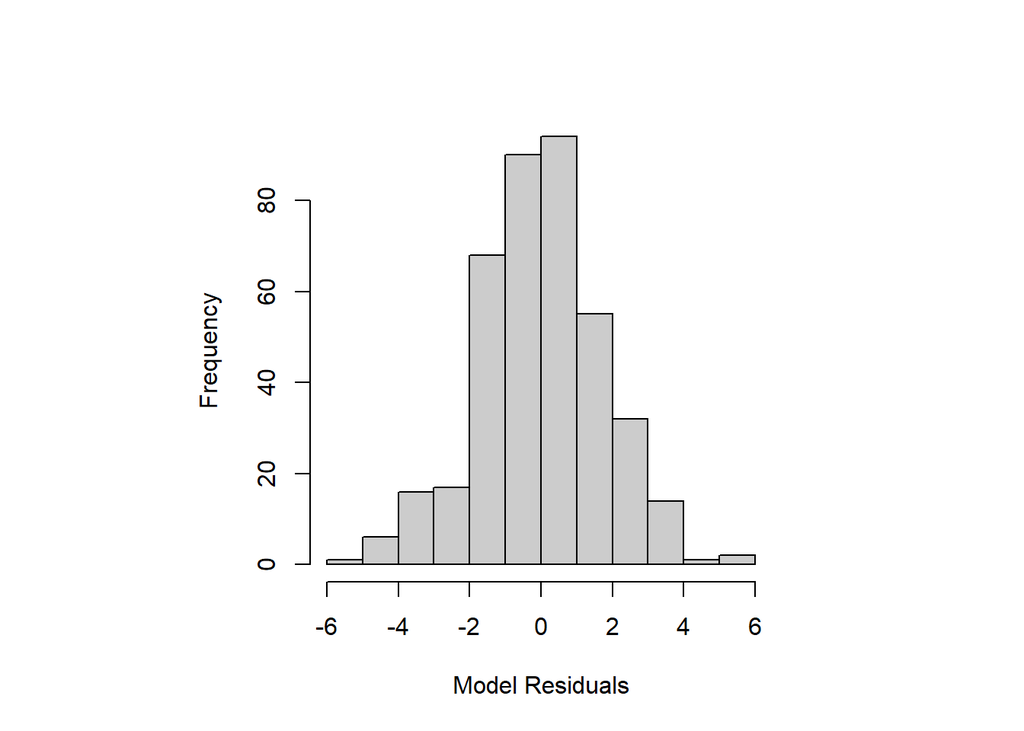

```r
par(pty='s')
hist(residuals(MHC.gam, type = "response"), main = NA, xlab = "Model Residuals", col = "grey80")
```

Residuals are normally distributed around 0

Check to see if elevation is adequately smoothed

```r
k.check(MHC.gam)
```

```
##              k'       edf   k-index p-value
## s(Site.ID)   37 20.139398        NA      NA
## s(elevation)  9  3.726649 0.8916021   0.015
```

Elevation could be smoothed further, but changing the knots does not improve this. For the sake of comparison, we keep elevation as is so that this model may be directly compared with all others.

Check for overdispersion

```r
sum(residuals(MHC.gam, type = "pearson")^2) / df.residual(MHC.gam)
```

```
## [1] 3.235565
```

The residuals are not overdispersed

Run GAM summary for results

```r
summary(MHC.gam)
```

```
##
## Family: gaussian
## Link function: identity
##
## Formula:
## C.b.coll. ~ s(Site.ID, bs = "re") + Temp_Mean + s(elevation) +
##     Precip_Mean + Temp_Mean_Seasonality
##
## Parametric coefficients:
##                         Estimate Std. Error t value Pr(>|t|)
## (Intercept)           -12.266262   3.131547  -3.917 0.000107 ***
## Temp_Mean               0.042257   0.165632   0.255 0.798766
## Precip_Mean            -0.019039   0.383480  -0.050 0.960430
## Temp_Mean_Seasonality  -0.008408   0.009279  -0.906 0.365492
## ---
## Signif. codes:  0 '***' 0.001 '**' 0.01 '*' 0.05 '.' 0.1 ' ' 1
##
## Approximate significance of smooth terms:
##                 edf Ref.df      F  p-value
## s(Site.ID)   20.139 36.000  2.679  < 2e-16 ***
## s(elevation)  3.727  3.931 10.547 5.16e-07 ***
## ---
## Signif. codes:  0 '***' 0.001 '**' 0.01 '*' 0.05 '.' 0.1 ' ' 1
##
## R-sq.(adj) =  0.549   Deviance explained =   58%
## -REML = 829.13  Scale est. = 3.2356    n = 396
```

5.8C Late Intermediate Period (LIP)

Check for collinearity problems among the LIP individuals with Nitrogen values

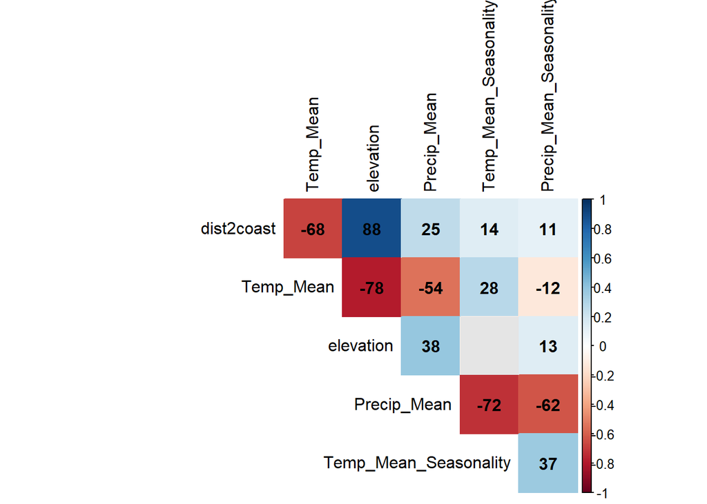

```r
#before calculate this reduce dataset to only those with N or C
LIP_N <- subset(dat.lip, !is.na(dat.lip$N.b.coll.))#leave out individuals with NA for N bone coll

#build a data frame of predictor variables
LIPN_AllVars_Pred<-with(LIP_N,
             data.frame(
                    dist2coast, #Distance to the Coast (m)
                    Temp_Mean, #Mean Temperature (c)
                    elevation, #Elevation above sea level (masl)
                    Precip_Mean, #Mean Precipitation (mm)
                    Temp_Mean_Seasonality, #Mean seasonality of temperature over the year
                    Precip_Mean_Seasonality #Mean seasonality of precipitation over the year
             )
           )

#then test collinearity
cm<- cor(LIPN_AllVars_Pred,
         method="pearson",
         use="pairwise.complete.obs")


# matrix of the p-value of the correlation
p.mat<-cor.mtest(LIPN_AllVars_Pred)

#plot the correlation matrix
corrplot(cm,
      method="color",
      type="upper",
      diag=FALSE,
      bg="grey90",
      addCoef.col = "black",
      tl.col="black",
      outline = FALSE,
      addCoefasPercent=TRUE,
      p.mat = p.mat, sig.level = 0.05, insig = "blank"
  )
```

Run the LIP Nitrogen GAM

```r
LIPNgam <- gam(N.b.coll.~ s(elevation) + Precip_Mean  + Precip_Mean_Seasonality +s(Site.ID, bs = "re"),
                     family = gaussian(link = "identity"),
                     method = "REML",
                     data=LIP_N[order(-LIP_N$Start.BP),]
                    )
```

Check model residuals

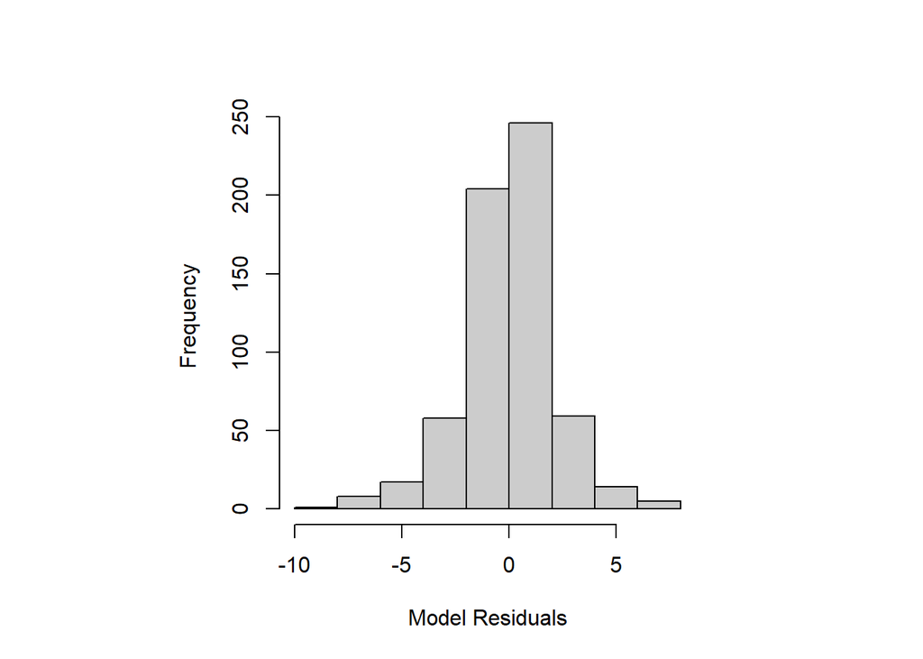

```r
par(pty='s')
hist(residuals(LIPNgam, type = "response"), main = NA, xlab = "Model Residuals", col = "grey80")
```

Residuals are normally distributed around 0

Check to see if elevation is adequately smoothed

```r
k.check(LIPNgam)
```

```
##              k'       edf   k-index p-value
## s(elevation)  9  1.000663 0.9085479   0.005
## s(Site.ID)   34 26.995723        NA      NA
```

Check for overdispersion

```r
sum(residuals(LIPNgam, type = "pearson")^2) / df.residual(LIPNgam)
```

```
## [1] 4.765489
```

The model is not overdispersed

Run GAM summary for results

```r
summary(LIPNgam)
```

```
##
## Family: gaussian
## Link function: identity
##
## Formula:
## N.b.coll. ~ s(elevation) + Precip_Mean + Precip_Mean_Seasonality +
##     s(Site.ID, bs = "re")
##
## Parametric coefficients:
##                         Estimate Std. Error t value Pr(>|t|)
## (Intercept)             16.44586    4.91008   3.349 0.000862 ***
## Precip_Mean             -1.81035    0.78917  -2.294 0.022146 *
## Precip_Mean_Seasonality  0.03218    5.07874   0.006 0.994947
## ---
## Signif. codes:  0 '***' 0.001 '**' 0.01 '*' 0.05 '.' 0.1 ' ' 1
##
## Approximate significance of smooth terms:
##                 edf Ref.df      F p-value
## s(elevation)  1.001  1.001  0.202   0.653
## s(Site.ID)   26.996 32.000 20.400  <2e-16 ***
## ---
## Signif. codes:  0 '***' 0.001 '**' 0.01 '*' 0.05 '.' 0.1 ' ' 1
##
## R-sq.(adj) =   0.64   Deviance explained = 65.8%
## -REML = 1389.2  Scale est. = 4.7655    n = 612
```

Check for collinearity problems among the LIP individuals with Carbon values

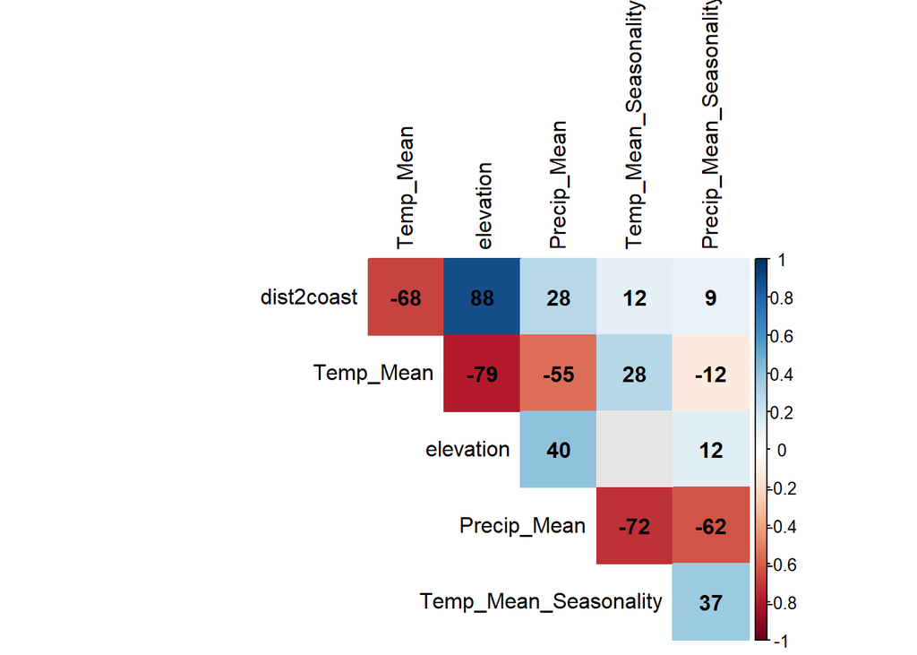

```r
#before calculate this reduce dataset to only those with N or C
LIP_C <- subset(dat.lip, !is.na(dat.lip$C.b.coll.))#leave out individuals with NA for C bone coll

#build a data frame of predictor variables
LIPC_AllVars_Pred<-with(LIP_C,
             data.frame(
                    dist2coast, #Distance to the Coast (m)
                    Temp_Mean, #Mean Temperature (c)
                    elevation, #Elevation above sea level (masl)
                    Precip_Mean, #Mean Precipitation (mm)
                    Temp_Mean_Seasonality, #Mean seasonality of temperature over the year
                    Precip_Mean_Seasonality #Mean seasonality of precipitation over the year
             )
           )

#then test collinearity
cm<- cor(LIPC_AllVars_Pred,
         method="pearson",
         use="pairwise.complete.obs")


# matrix of the p-value of the correlation
p.mat<-cor.mtest(LIPC_AllVars_Pred)

#plot the correlation matrix
corrplot(cm,
      method="color",
      type="upper",
      diag=FALSE,
      bg="grey90",
      addCoef.col = "black",
      tl.col="black",
      outline = FALSE,
      addCoefasPercent=TRUE,
      p.mat = p.mat, sig.level = 0.05, insig = "blank"
  )
```

Run the LIP Carbon GAM

```r
LIPC.gam <- gam(C.b.coll.~ s(elevation) + Precip_Mean + Precip_Mean_Seasonality +s(Site.ID, bs = "re"),
                     family = gaussian(link = "identity"),
                     method = "REML",
                     data=LIP_C[order(-LIP_C$Start.BP),]
                    )
```

Check model residuals

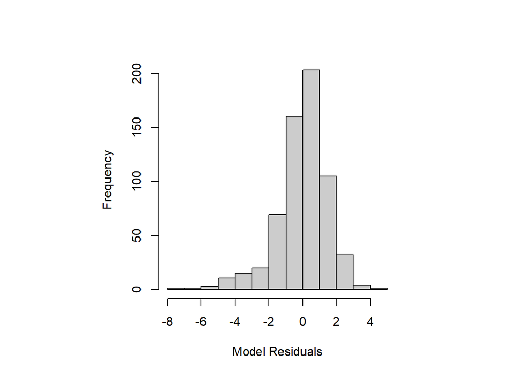

```r
par(pty='s')
hist(residuals(LIPC.gam, type = "response"), main = NA, xlab = "Model Residuals", col = "grey80")
```

There is slight skew, but generally the residuals are normally distributed around 0

Check for adequate smoothing of elevation

```r
k.check(LIPC.gam)
```

```
##              k'       edf   k-index p-value
## s(elevation)  9  3.648798 0.9582962   0.115
## s(Site.ID)   37 24.474831        NA      NA
```

Elevation is adequately smoothed

Check for overdispersion

```r
sum(residuals(LIPC.gam, type = "pearson")^2) / df.residual(LIPC.gam)
```

```
## [1] 2.412485
```

Model residuals are not overdispersed

Run GAM summary for results

```r
summary(LIPC.gam)
```

```
##
## Family: gaussian
## Link function: identity
##
## Formula:
## C.b.coll. ~ s(elevation) + Precip_Mean + Precip_Mean_Seasonality +
##     s(Site.ID, bs = "re")
##
## Parametric coefficients:
##                         Estimate Std. Error t value Pr(>|t|)
## (Intercept)             -18.7959     2.8951  -6.492 1.79e-10 ***
## Precip_Mean               0.8124     0.4183   1.942   0.0526 .
## Precip_Mean_Seasonality   5.9394     3.0320   1.959   0.0506 .
## ---
## Signif. codes:  0 '***' 0.001 '**' 0.01 '*' 0.05 '.' 0.1 ' ' 1
##
## Approximate significance of smooth terms:
##                 edf Ref.df      F p-value
## s(elevation)  3.649  3.815 11.954  <2e-16 ***
## s(Site.ID)   24.475 35.000  5.891  <2e-16 ***
## ---
## Signif. codes:  0 '***' 0.001 '**' 0.01 '*' 0.05 '.' 0.1 ' ' 1
##
## R-sq.(adj) =  0.528   Deviance explained =   55%
## -REML = 1201.4  Scale est. = 2.4125    n = 625
```

5.8D Late Horizon (LH)

Check for collinearity problems among the LH individuals with Nitrogen values

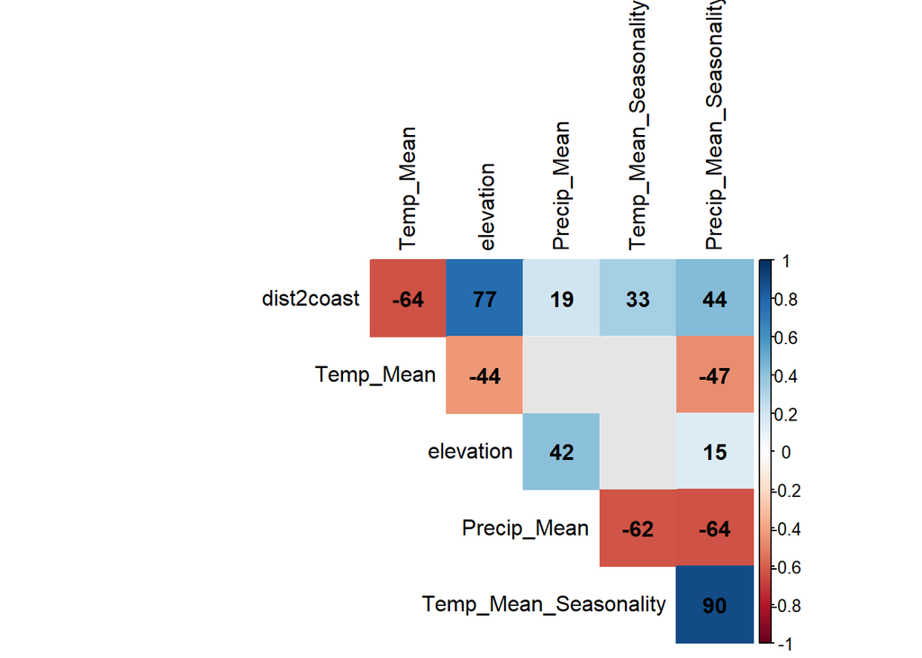

```r
#before calculate this reduce dataset to only those with N or C
LH_N <- subset(dat.lh, !is.na(dat.lh$N.b.coll.))#leave out individuals with NA for N bone coll


#build a data frame of predictor variables
LHPN_AllVars_Pred<-with(LH_N,
             data.frame(
                    dist2coast, #Distance to the Coast (m)
                    Temp_Mean, #Mean Temperature (c)
                    elevation, #Elevation above sea level (masl)
                    Precip_Mean, #Mean Precipitation (mm)
                    Temp_Mean_Seasonality, #Mean seasonality of temperature over the year
                    Precip_Mean_Seasonality #Mean seasonality of precipitation over the year
             )
           )

#then test collinearity
cm<- cor(LHPN_AllVars_Pred,
         method="pearson",
         use="pairwise.complete.obs")


# matrix of the p-value of the correlation
p.mat<-cor.mtest(LHPN_AllVars_Pred)

#plot the correlation matrix
corrplot(cm,
      method="color",
      type="upper",
      diag=FALSE,
      bg="grey90",
      addCoef.col = "black",
      tl.col="black",
      outline = FALSE,
      addCoefasPercent=TRUE,
      p.mat = p.mat, sig.level = 0.05, insig = "blank"
  )
```

Elevation and dist2coast are highly correlated (>0.70) and therefore including both is problematic. We drop distance 2 coast in favor of elevation . Precip_Mean_Seasonality and Temp_Mean_Seasonality are also >0.70. We drop Precip_Seasonality for comparability, in all other periods where predictor variables are dropped precip_mean_seasonality is among those removed and we do so again here.

Run LH nitrogen GAM

```r
LHNgam <- gam(N.b.coll.~ Temp_Mean + s(elevation, k = 3) +Precip_Mean + Temp_Mean_Seasonality +s(Site.ID, bs = "re"),
                     family = gaussian(link = "identity"),
                     method = "REML",
                     data=LH_N[order(-LH_N$Start.BP),]
                    )
```

Check model residuals

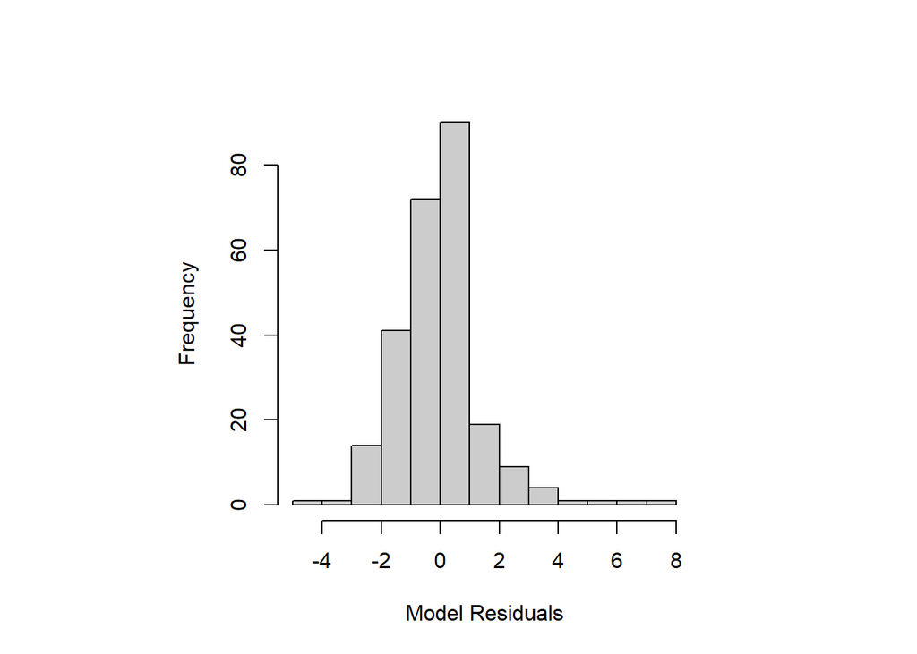

```r
par(pty='s')
hist(residuals(LHNgam, type = "response"), main = NA, xlab = "Model Residuals", col = "grey80")
```

There is slight skew, but the residuals are mostly normally distributed around 0

Check if elevation is adequately smoothed

```r
k.check(LHNgam)
```

```
##              k'      edf   k-index p-value
## s(elevation)  2 1.901804 0.8680879    0.02
## s(Site.ID)   10 3.027624        NA      NA
```

Check for overdispersion

```r
sum(residuals(LHNgam, type = "pearson")^2) / df.residual(LHNgam)
```

```
## [1] 2.090122
```

Residuals are not overdispersed

Run GAM summary for results

```r
summary(LHNgam)
```

```
##
## Family: gaussian
## Link function: identity
##
## Formula:
## N.b.coll. ~ Temp_Mean + s(elevation, k = 3) + Precip_Mean + Temp_Mean_Seasonality +
##     s(Site.ID, bs = "re")
##
## Parametric coefficients:
##                       Estimate Std. Error t value Pr(>|t|)
## (Intercept)           -2.58270    2.33395  -1.107    0.270
## Temp_Mean              0.29515    0.19437   1.519    0.130
## Precip_Mean           -0.57220    0.45669  -1.253    0.211
## Temp_Mean_Seasonality  0.10137    0.01504   6.742  1.1e-10 ***
## ---
## Signif. codes:  0 '***' 0.001 '**' 0.01 '*' 0.05 '.' 0.1 ' ' 1
##
## Approximate significance of smooth terms:
##                edf Ref.df     F p-value
## s(elevation) 1.902  1.909 5.818 0.01467 *
## s(Site.ID)   3.028  5.000 2.193 0.00603 **
## ---
## Signif. codes:  0 '***' 0.001 '**' 0.01 '*' 0.05 '.' 0.1 ' ' 1
##
## R-sq.(adj) =  0.893   Deviance explained = 89.7%
## -REML = 470.09  Scale est. = 2.0901    n = 255
```

Check for collinearity problems among the LH individuals with Carbon values

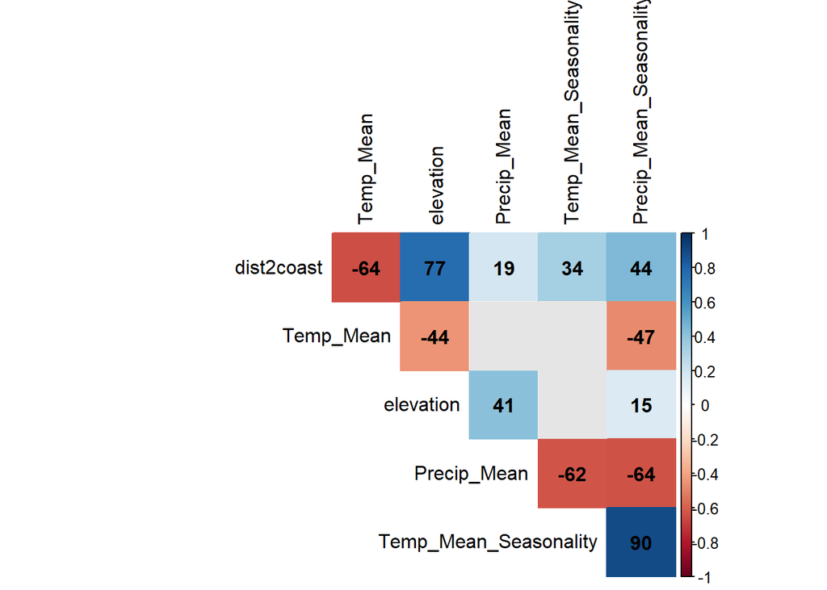

```r
#before calculate this reduce dataset to only those with N or C
LH_C <- subset(dat.lh, !is.na(dat.lh$C.b.coll.))#leave out individuals with NA for C bone coll


#build a data frame of predictor variables
LHC_AllVars_Pred<-with(LH_C,
             data.frame(
                    dist2coast, #Distance to the Coast (m)
                    Temp_Mean, #Mean Temperature (c)
                    elevation, #Elevation above sea level (masl)
                    Precip_Mean, #Mean Precipitation (mm)
                    Temp_Mean_Seasonality, #Mean seasonality of temperature over the year
                    Precip_Mean_Seasonality #Mean seasonality of precipitation over the year
             )
           )


#then test collinearity
cm<- cor(LHC_AllVars_Pred,
         method="pearson",
         use="pairwise.complete.obs")


# matrix of the p-value of the correlation
p.mat<-cor.mtest(LHC_AllVars_Pred)

#plot the correlation matrix
corrplot(cm,
      method="color",
      type="upper",
      diag=FALSE,
      bg="grey90",
      addCoef.col = "black",
      tl.col="black",
      outline = FALSE,
      addCoefasPercent=TRUE,
      p.mat = p.mat, sig.level = 0.05, insig = "blank"
  )
```

Elevation and dist2coast are highly correlated (>0.70) and therefore including both is problematic. We drop distance 2 coast in favor of elevation. Precip_Mean_Seasonality and Temp_Mean_Seasonality are also >0.70. We drop Precip_Seasonality for comparability, in all other periods where predictor variables are dropped precip_mean_seasonality is among those removed and we do so again here.

Run the LH Carbon GAM

```r
LHC.gam <- gam(C.b.coll.~ Temp_Mean + s(elevation, k = 3) +Precip_Mean + Temp_Mean_Seasonality +s(Site.ID, bs = "re"),
                     family = gaussian(link = "identity"),
                     method = "REML",
                     data=LH_C[order(-LH_C$Start.BP),]
                    )
```

Check model residuals

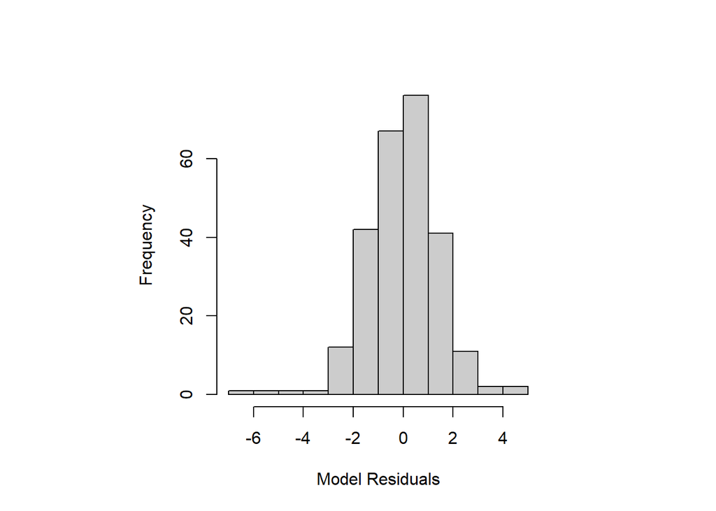

```r
par(pty='s')
hist(residuals(LHC.gam, type = "response"), main = NA, xlab = "Model Residuals", col = "grey80")
```

Residuals are normally distributed around 0

Check for adequate smoothing of elevation

```r
k.check(LHC.gam)
```

```
##              k'      edf   k-index p-value
## s(elevation)  2 1.000960 0.8613065   0.015
## s(Site.ID)   10 3.830602        NA      NA
```

Elevation could be smoothed further, but changing the knots does not improve this. For the sake of comparison, we keep elevation as is so that this model may be directly compared with all others.

Check for overdispersion

```r
sum(residuals(LHC.gam, type = "pearson")^2) / df.residual(LHC.gam)
```

```
## [1] 2.184405
```

Residuals are not overdispersed

Run GAM summary for results

```r
summary(LHC.gam)
```

```
##
## Family: gaussian
## Link function: identity
##
## Formula:
## C.b.coll. ~ Temp_Mean + s(elevation, k = 3) + Precip_Mean + Temp_Mean_Seasonality +
##     s(Site.ID, bs = "re")
##
## Parametric coefficients:
##                        Estimate Std. Error t value Pr(>|t|)
## (Intercept)           -8.258902   2.219493  -3.721 0.000245 ***
## Temp_Mean             -0.338022   0.115980  -2.914 0.003888 **
## Precip_Mean            0.208256   0.336541   0.619 0.536607
## Temp_Mean_Seasonality  0.009993   0.011713   0.853 0.394427
## ---
## Signif. codes:  0 '***' 0.001 '**' 0.01 '*' 0.05 '.' 0.1 ' ' 1
##
## Approximate significance of smooth terms:
##                edf Ref.df     F  p-value
## s(elevation) 1.001  1.001 9.523  0.00223 **
## s(Site.ID)   3.831  6.000 3.598 7.94e-05 ***
## ---
## Signif. codes:  0 '***' 0.001 '**' 0.01 '*' 0.05 '.' 0.1 ' ' 1
##
## R-sq.(adj) =  0.442   Deviance explained = 45.9%
## -REML = 478.01  Scale est. = 2.1844    n = 257
```

Run a complete model with all individuals

Check for collinearity problems among the individuals with Nitrogen values

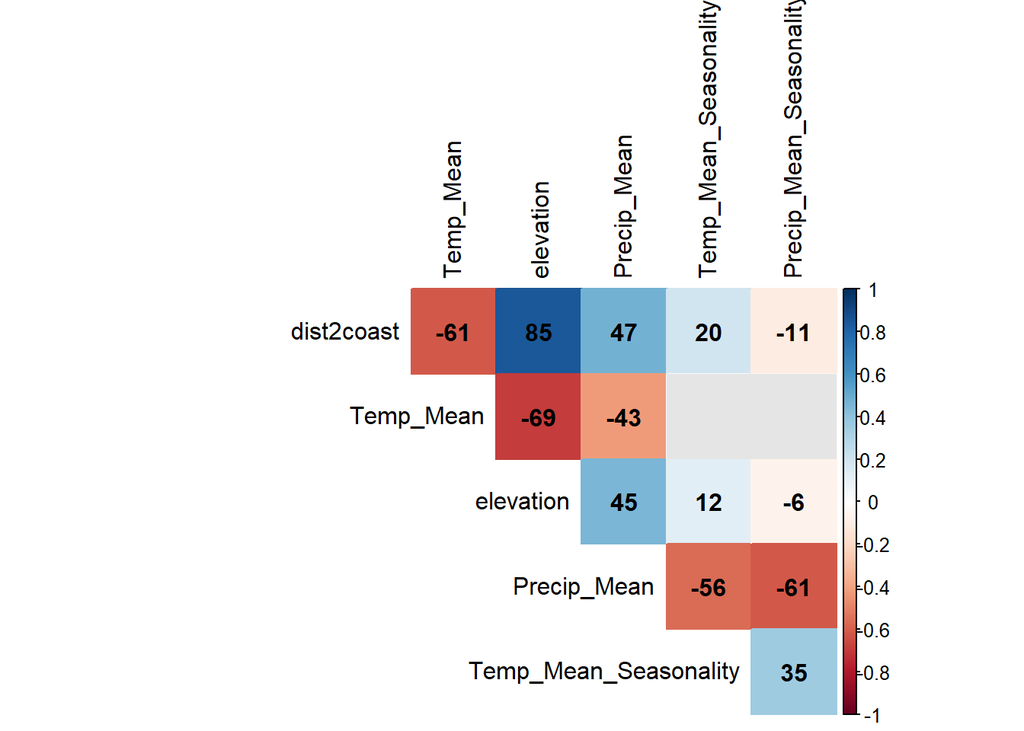

```r
#before calculate this reduce dataset to only those with N or C
dat_N <- subset(dat.all, !is.na(dat.all$N.b.coll.))#leave out individuals with NA for N bone coll

#Create a function for identifying collinearity among variables
cor.mtest <- function(mat) {
    mat <- as.matrix(mat)
    n <- ncol(mat)
    p.mat<- matrix(NA, n, n)
    diag(p.mat) <- 0
    for (i in 1:(n - 1)) {
        for (j in (i + 1):n) {
            tmp <- cor.test(mat[, i], mat[, j])
            p.mat[i, j] <- p.mat[j, i] <- tmp$p.value
        }
    }
  colnames(p.mat) <- rownames(p.mat) <- colnames(mat)
  p.mat
}


#build a data frame of predictor variables
dat_AllVars_Pred<-with(dat_N,
             data.frame(
                    dist2coast, #Distance to the Coast (m)
                    Temp_Mean, #Mean Temperature (c)
                    elevation, #Elevation above sea level (masl)
                    Precip_Mean, #Mean Precipitation (mm)
                    Temp_Mean_Seasonality, #Mean seasonality of temperature over the year
                    Precip_Mean_Seasonality #Mean seasonality of precipitation over the year
             )
           )

#then test collinearity
cm<- cor(dat_AllVars_Pred,
         method="pearson",
         use="pairwise.complete.obs")


# matrix of the p-value of the correlation
p.mat<-cor.mtest(dat_AllVars_Pred)

#plot the correlation matrix
corrplot(cm,
      method="color",
      type="upper",
      diag=FALSE,
      bg="grey90",
      addCoef.col = "black",
      tl.col="black",
      outline = FALSE,
      addCoefasPercent=TRUE,
      p.mat = p.mat, sig.level = 0.05, insig = "blank"
  )
```

Elevation and dist2coast are highly correlated (>0.70) and therefore including both is problematic. We drop distance 2 coast in favor of elevation. All other variables are < 0.70 in the collinearity matrix and therefore are fine to include in the model.

Run the GAM for all individuals with Nitrogen

```r
dat_N$Site.ID <- as.factor(dat_N$Site.ID)

dat.par.gam <- gam(N.b.coll.~ Temp_Mean + s(elevation) + Precip_Mean + Temp_Mean_Seasonality + Precip_Mean_Seasonality +s(Site.ID, bs = "re"),
                     family = gaussian(link = "identity"),
                     method = "REML",
                     data=dat_N[order(-dat_N$Start.BP),]
                    )
```

Check model residuals

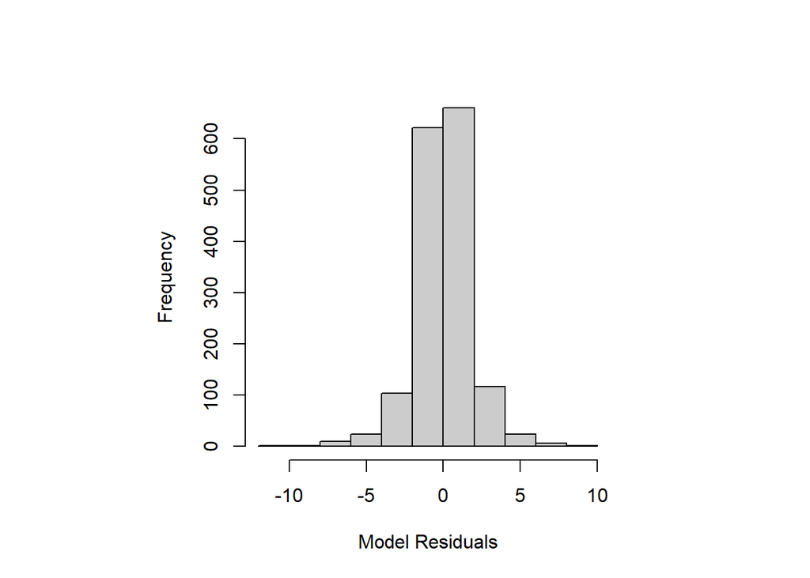

```r
par(pty='s')
hist(residuals(dat.par.gam, type = "response"), main = NA, xlab = "Model Residuals", col = "grey80")
```

Residuals are normally distributed around 0

Check for adequate smoothing of elevation

```r
k.check(dat.par.gam)
```

```
##               k'        edf   k-index p-value
## s(elevation)   9   6.629279 0.9397507   0.005
## s(Site.ID)   121 100.614083        NA      NA
```

Elevation could be smoothed further, but we elect to retain consistency with the other models.

Check for overdispersion

```r
sum(residuals(dat.par.gam, type = "pearson")^2) / df.residual(dat.par.gam)
```

```
## [1] 3.376341
```

Model residuals are not overdispersed

Run GAM summary for results

```r
summary(dat.par.gam)
```

```
##
## Family: gaussian
## Link function: identity
##
## Formula:
## N.b.coll. ~ Temp_Mean + s(elevation) + Precip_Mean + Temp_Mean_Seasonality +
##     Precip_Mean_Seasonality + s(Site.ID, bs = "re")
##
## Parametric coefficients:
##                           Estimate Std. Error t value Pr(>|t|)
## (Intercept)              28.859649   4.268308   6.761 1.97e-11 ***
## Temp_Mean                -0.332369   0.148476  -2.239   0.0253 *
## Precip_Mean              -2.515339   0.438742  -5.733 1.20e-08 ***
## Temp_Mean_Seasonality     0.023187   0.009388   2.470   0.0136 *
## Precip_Mean_Seasonality -12.933147   2.770474  -4.668 3.32e-06 ***
## ---
## Signif. codes:  0 '***' 0.001 '**' 0.01 '*' 0.05 '.' 0.1 ' ' 1
##
## Approximate significance of smooth terms:
##                  edf  Ref.df      F  p-value
## s(elevation)   6.629   6.709  5.317 6.72e-06 ***
## s(Site.ID)   100.614 120.000 21.923  < 2e-16 ***
## ---
## Signif. codes:  0 '***' 0.001 '**' 0.01 '*' 0.05 '.' 0.1 ' ' 1
##
## R-sq.(adj) =  0.832   Deviance explained = 84.4%
## -REML = 3373.9  Scale est. = 3.3763    n = 1570
```

Check for collinearity problems among the individuals with Carbon values

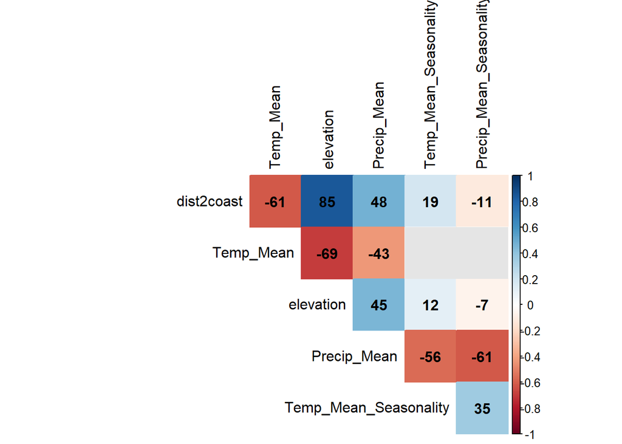

```r
#before calculate this reduce dataset to only those with N or C
dat_C <- subset(dat.all, !is.na(dat.all$C.b.coll.))#leave out individuals with NA for C bone coll


#build a data frame of predictor variables
datC_AllVars_Pred<-with(dat_C,
             data.frame(
                    dist2coast, #Distance to the Coast (m)
                    Temp_Mean, #Mean Temperature (c)
                    elevation, #Elevation above sea level (masl)
                    Precip_Mean, #Mean Precipitation (mm)
                    Temp_Mean_Seasonality, #Mean seasonality of temperature over the year
                    Precip_Mean_Seasonality #Mean seasonality of precipitation over the year
             )
           )

#then test collinearity
cm<- cor(datC_AllVars_Pred,
         method="pearson",
         use="pairwise.complete.obs")


# matrix of the p-value of the correlation
p.mat<-cor.mtest(datC_AllVars_Pred)

#plot the correlation matrix
corrplot(cm,
      method="color",
      type="upper",
      diag=FALSE,
      bg="grey90",
      addCoef.col = "black",
      tl.col="black",
      outline = FALSE,
      addCoefasPercent=TRUE,
      p.mat = p.mat, sig.level = 0.05, insig = "blank"
  )
```

Elevation and dist2coast are highly correlated (>0.70) and therefore including both is problematic. We drop distance 2 coast in favor of elevation. All other variables are < 0.70 in the collinearity matrix and therefore are fine to include in the model.

Run the GAM for all individuals with Carbon

```r
dat_C$Site.ID <- as.factor(dat_C$Site.ID)

datC.gam <- gam(C.b.coll.~ Temp_Mean + s(elevation) + Precip_Mean + Temp_Mean_Seasonality + Precip_Mean_Seasonality +s(Site.ID, bs = "re"),
                     family = gaussian(link = "identity"),
                     method = "REML",
                     data=dat_C[order(-dat_C$Start.BP),]
                    )
```

Check model residuals

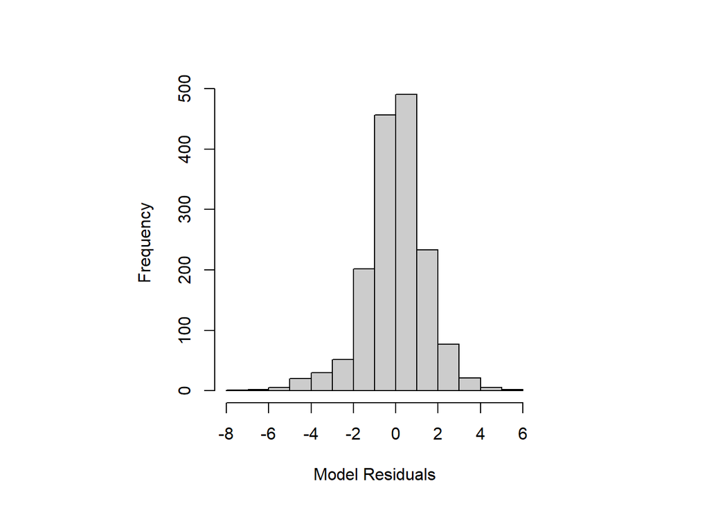

```r
par(pty='s')
hist(residuals(datC.gam, type = "response"), main = NA, xlab = "Model Residuals", col = "grey80")
```

Residuals are normally distributed around 0

Check for adequate smoothing of elevation

```r
k.check(datC.gam)
```

```
##               k'      edf   k-index p-value
## s(elevation)   9  5.62910 0.9281037       0
## s(Site.ID)   125 97.02358        NA      NA
```

Elevation could be smoothed further, but changing the knots does not improve this. For the sake of comparison, we keep elevation as is so that this model may be directly compared with all others.

Check for overdispersion

```r
sum(residuals(datC.gam, type = "pearson")^2) / df.residual(datC.gam)
```

```
## [1] 2.274778
```

Model residuals are not overdispersed

Run GAM summary for results

```r
summary(datC.gam)
```

```
##
## Family: gaussian
## Link function: identity
##
## Formula:
## C.b.coll. ~ Temp_Mean + s(elevation) + Precip_Mean + Temp_Mean_Seasonality +
##     Precip_Mean_Seasonality + s(Site.ID, bs = "re")
##
## Parametric coefficients:
##                          Estimate Std. Error t value Pr(>|t|)
## (Intercept)             -8.143440   2.431019  -3.350 0.000829 ***
## Temp_Mean               -0.156412   0.081573  -1.917 0.055372 .
## Precip_Mean             -0.156445   0.245408  -0.637 0.523905
## Temp_Mean_Seasonality   -0.016458   0.005196  -3.167 0.001570 **
## Precip_Mean_Seasonality -0.405525   1.614205  -0.251 0.801677
## ---
## Signif. codes:  0 '***' 0.001 '**' 0.01 '*' 0.05 '.' 0.1 ' ' 1
##
## Approximate significance of smooth terms:
##                 edf  Ref.df      F p-value
## s(elevation)  5.629   5.788 12.571  <2e-16 ***
## s(Site.ID)   97.024 124.000  9.849  <2e-16 ***
## ---
## Signif. codes:  0 '***' 0.001 '**' 0.01 '*' 0.05 '.' 0.1 ' ' 1
##
## R-sq.(adj) =  0.659   Deviance explained = 68.1%
## -REML = 3074.2  Scale est. = 2.2748    n = 1596
```

Make Figure 3 - comparison of deviances explained

```r
#take the amount of the deviance explained for each time period and put it in a table
n.table <- data.frame(period=c("EIP", "MH", "LIP", "LH"), dev.ex=c(92.3, 72.3, 65.8, 89.7))
n.table
```

```
##   period dev.ex
## 1    EIP   92.3
## 2     MH   72.3
## 3    LIP   65.8
## 4     LH   89.7
```

```r
c.table <- data.frame(period=c("EIP", "MH", "LIP", "LH"), dev.ex=c(88.9, 58.0, 55.0, 45.9))
c.table
```

```
##   period dev.ex
## 1    EIP   88.9
## 2     MH   58.0
## 3    LIP   55.0
## 4     LH   45.9
```

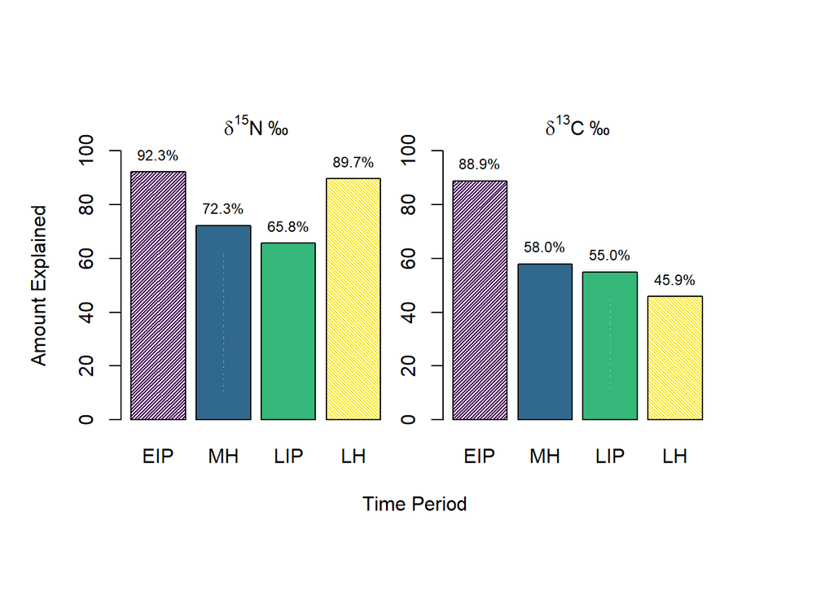

```r
#png("Fig3.model_deviance_exp.png", width=8, height=8, units="in", res=300)
par(pty="s", mfrow=c(1,2), mar=c(5.1, 5.1, 4.1, 1.1), xpd=TRUE)
nbp <- barplot(n.table$dev.ex, ylim = c(0, 100), ylab = "Amount Explained", col=viridis(4), xlab = "", names.arg=c("EIP", "MH", "LIP", "LH"), density = c(50, 100, 100, 50), angle = c(45, 135, 45, 135))
text(x=nbp, y=n.table$dev.ex, label = c("92.3%", "72.3%", "65.8%", "89.7%"), pos = 3, cex= 0.75)
text(x=2.5, y=110, label=expression({delta}^15*N~'\u2030'))

par(mar=c(5.1, 1.1, 4.1, 5.1))
cbp <- barplot(c.table$dev.ex, ylim = c(0, 100), ylab = "", col=viridis(4), xlab = "", names.arg=c("EIP", "MH", "LIP", "LH"), density = c(50, 100, 100, 50), angle = c(45, 135, 45, 135))
text(x=cbp, y=c.table$dev.ex, label = c("88.9%", "58.0%", "55.0%", "45.9%"), pos = 3, cex= 0.75)
text(x=2.5, y=110, label=expression({delta}^13*C~'\u2030'))

mtext("Time Period", side = 1, line = 3, at = -.5)
```

```r
#dev.off()

#reduce mar of right side in left plot and left side in right plot (equal amount) by using par for each of them.
```

Create objects with residuals for stripchart plotting

```r
Nitrogen.resids <- data.frame(cbind(residuals(EIP.par.gam, type = "response"), residuals(MHNgam, type = "response"), residuals(LIPNgam, type = "response"), residuals(LHNgam, type = "response")))
colnames(Nitrogen.resids) <- c("EIP", "MH", "LIP", "LH")

Carbon.resids <- data.frame(cbind(residuals(EIPC.gam, type = "response"), residuals(MHC.gam, type = "response"), residuals(LIPC.gam, type = "response"), residuals(LHC.gam, type = "response")))
colnames(Carbon.resids) <- c("EIP", "MH", "LIP", "LH")
```

Make Figure 4 - distribution of residuals

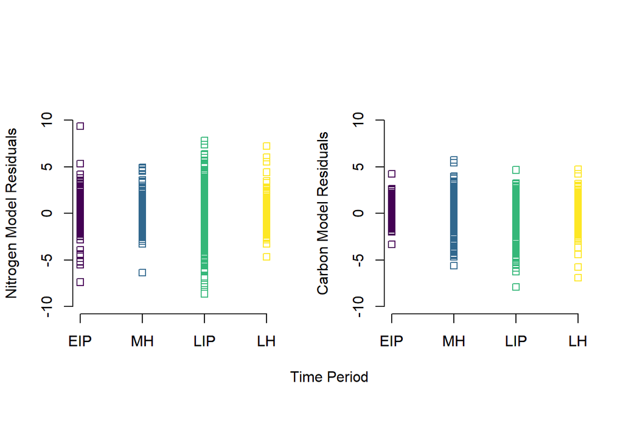

```r
#png("Fig4.model_residuals.png", width=8, height=8, units="in", res=300)
par(pty = "s", mfrow = c(1,2), bty = 'n')
stripchart(Nitrogen.resids, group.names = c("EIP", "MH", "LIP", "LH"), vertical = TRUE, col=viridis(4), ylab = "Nitrogen Model Residuals", ylim = c(-10,10))
#boxplot(Nitrogen.resids, xlab = "Period", ylab = "Residuals", xaxt = "n")
axis(1, at = seq(1,4,1), labels = c("EIP", "MH", "LIP", "LH"))

stripchart(Carbon.resids, group.names = c("EIP", "MH", "LIP", "LH"), vertical = TRUE, col=viridis(4), ylab = "Carbon Model Residuals", ylim = c(-10,10))
#boxplot(Carbon.resids, xlab = "Period", ylab = "Residuals", xaxt = "n")
axis(1, at = seq(1,4,1), labels = c("EIP", "MH", "LIP", "LH"))
mtext("Time Period", side = 1, line = 3, at = 0)
```

```r
#dev.off()
```

References Dormann, Carsten F., Jane Elith, Sven Bacher, Carsten Buchmann, Gudrun Carl, Gabriel Carre, Jaime R. Garcia Marquez et al. (2013). Collinearity: a review of methods to deal with it and a simulation study evaluating their performance. *Ecography* 36: 27-46.

Pulgar Vidal, J., (1981). Geografía del Perú: Las ocho regiones naturales del Perú, 8th ed., Editorial Universo, Lima, Peru.

Wilson, Kurt M., McCool, Weston C., Brewer, Simon C., Zamora-Wilson Nicole, Schryver, Percy J., Lamson, Roxanne Lois F., Huggard, Ashlyn M., Brenner Coltrain, Joan, Contreras, Daniel A., Codding, Brian F. Climate, not Population Size, is the Primary Influence of Homogenizing Dietary Variation in the Prehispanic Central Andes. Submitted to *Science Advances* (2021).